# 텍스트분석 뉴스레터: 2023년 6월

sung won kang

2023 7 3

- 한국환경연구원 텍스트 수집 도구는 2023년 6월 30일까지 네이버 기사 데이터와 환경부 문헌 데이터를 제공한다. 아래 뉴스레터에서는 2023년 6월 30일을 기점으로 30일 이전까지 수집한 자료를 사용한다.

### A. Text 데이터

분석 대상 Text Data는 다음 두 종류의 문헌을 자료이다.

1. NAVER 환경 뉴스 : 2023년 6월 1일-2023년 6월 30일 NAVER 뉴스> ‘사회’ >‘환경’ 부문에 게시된 뉴스
2. 환경부 문건 : 2023년 6월 1일-2023년 6월 30일 환경부홈페이지에 게시된 환경부 보도자료 및 e-환경뉴스

’NAVER 환경 뉴스’는 환경정책의 수요자인 국민의 환경과 관련된 관심사를 전달하는 텍스트 자료이다. 그리고 ’환경부 문건’은 환경정책의 공급자인 환경부의 관심사를 전달하는 텍스트 자료이다. 이 두 자료의 키워드를 비교하여 환경정책 공급자의 관심사가 환경정책 수요자의 관심사에 조응하는지 여부를 점검한다.

### B. 키워드 빈도분석

한국환경연구원의 환경 빅데이터 플랫폼에서는 키워드를 단순빈도수 및 TF_IDF 값에 따라 추출한다. 키워드 추출 전단계로 파이선’konlpy’패키지를 활용한 형태소 분석 및 품사 태깅을 수행하고, 불용어(stopwords)를 제거한다. 2023년 6월 1일 - 6월 30일 게시 NAVER 환경뉴스 및 환경부 문건에서 단순빈도수가 높은 20개의 키워드를 추출한 결과는 아래 그림과 같다.

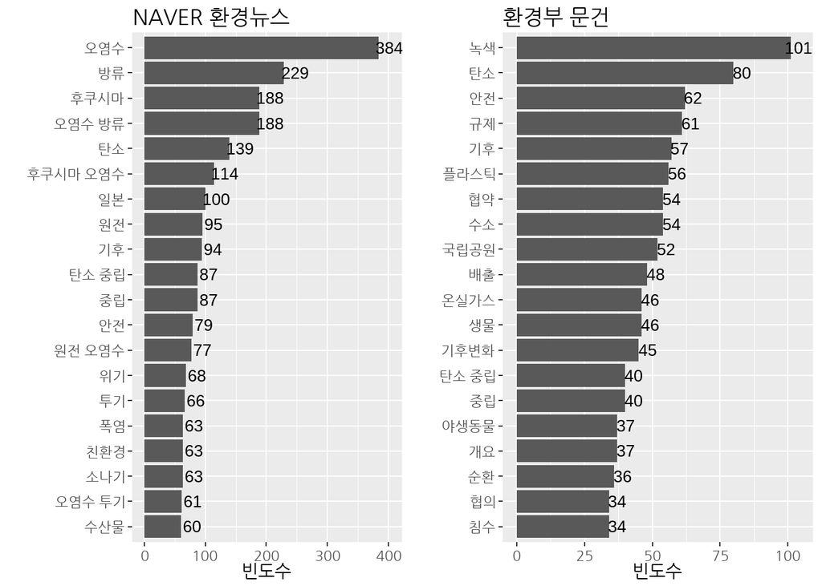

눈에 띄는 차이는 두 가지로 정리할 수 있다.

- 첫째, 네이버 환경뉴스에는 빈도수가 높은 상위 20개 키워드 중 ‘오염수’,‘후쿠시마’,‘오염수 방류’,‘방류’ 등 후쿠시마 제1원자력발전소 오염수 방류와 관련된 키워드 및 이상기후 현상 중 ‘폭염’,‘소나기’ 와 같은 키워드가 발견되었지만 환경부 문건의 빈도수 상위 20개 키워드에는 이에 상응하는 키워드가 발견되지 않았다.
- 둘째, 환경부 문건의 빈도수 상위 20개 키워드 중에는 ‘플라스틱’, ‘순환’ 등 순환경제 관련 키워드 및 ‘국립공원’,‘야생동물’,‘생물’ 등 자연환경 관련 키워드, 이상기후현상 중 ‘침수’ 키워드, 그리고 ‘규제’,‘수소’ 키워드가 포함되지만 네이버 환경뉴스에서는 이에 상응하는 키워드가 발견되지 않았다.

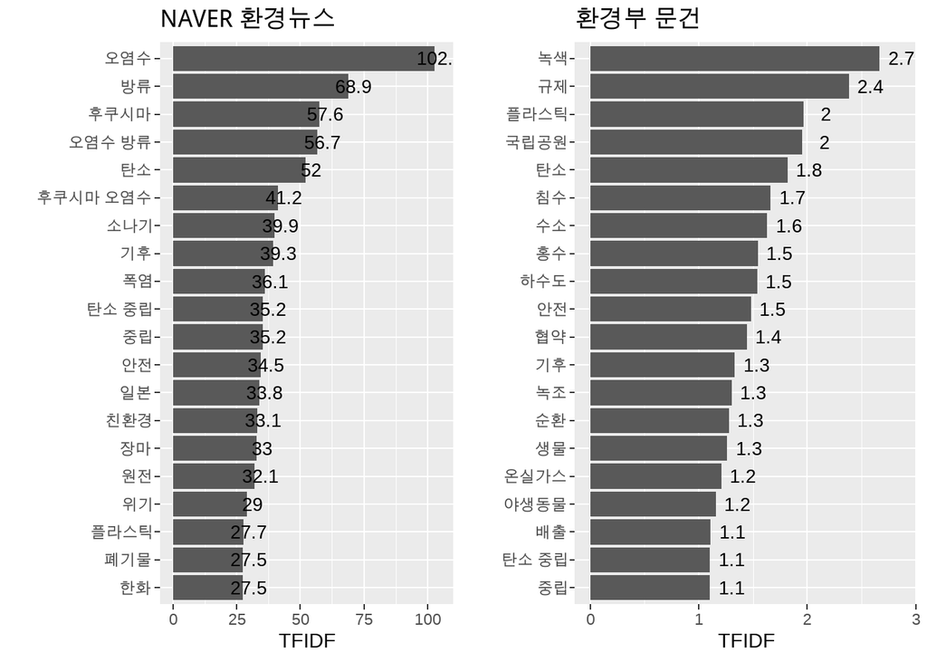

### C.키워드 관련 뉴스

네이버 환경뉴스 키워드와 환경부 문건 키워드간의 차이의 원인을 파악하기 위해서 두 문헌에서 단순빈도가 가장 높은 10개 키워드 중 서로 상이한 키워드가 포함된 문헌의 제목들을 비교하였다.

- 네이버 환경뉴스에서 단순빈도가 높은 10개 키워드 중 환경부 문건의 단순빈도가 높은 20개 키워드에 포함되지 않은 키워드는 [오염수, 방류, 후쿠시마, 오염수 방류, 후쿠시마 오염수, 일본, 원전]이다.
- 환경부 문헌에서 단순빈도가 높은 10개 키워드 중 네이버 환경뉴스에서 단순빈도가 높은 20개 키워드에 포함되지 않은 키워드는 [녹색, 규제, 플라스틱, 협약, 수소, 국립공원, 배출]이다.
1. ‘오염수’를 제목에 포함하는 기사들은 후쿠시마 제1원자력발전소 오염수 방류와 관련된 기사로 파악되었다. ’방류’,‘후쿠시마 오염수’,‘후쿠시마’, ‘오염수 방류’,’후쿠시마 오염수’를 제목에 포함하는 기사도 유사한 성향의 기사들이었다.

| Title |
| --- |
| ‘오염수 방류 위험’ 지적에 해수부 “근거 없다” 정면 반박 |
| 바다 낀 지자체, 日 오염수 방류 대응 분주…수산물 검사 확대 |
| 이재명 대표, 3일 부산 찾는다…日 오염수 방류 규탄 대회 참석 |
| 민주당 대전시당, 日오염수 해양투기 반대 서명운동 |
| 국방장관, 일본 오염수 질문에 “오염된 물 마시는 장병 없게 할 것” |
| IAEA ‘맹탕’ 보고서…오염수 처리 핵심 ALPS 성능은 빠졌다 |
| 민주당 제주, 日후쿠시마 오염수 방류 저지 서명 돌입 |
| 정의당 부울경 시도당, 원전 오염수 해양투기 중단 촉구 |
| IAEA “日 후쿠시마 원전 오염수 방사선핵종 분석방법, 목적 적합” |
| 이재명, 3일 부산 방문…원전 오염수 투기 규탄대회 참석 |

환경부 문헌에서 가장 빈도가 높은 10개 키워드 중 네이버 뉴스에서 가장 빈도가 높은 키워드 20개에 포함되지 않은 키워드는 “녹색”,“규제”,“플라스틱”,” “수소”, “국립공원”,“플라스틱”,“배출”이다. 이 중 “플라스틱”은 TFIDF 기준으로는 NAVER 환경뉴스 키워드에 포함된다. 2023년 6월 1일부터 6월 30일까지 게시된 환경부 문헌 중 이들 키워드를 제목에 포함하는 환경부 문헌은 다음과 같다.

1. ’녹색’을 제목에 포함하는 문헌들은 모두 녹색산업과 관련된 문헌이었다.

| Title |
| --- |
| 상수도관 등 녹색산업 수출기업 경쟁력 높인다 |
| 녹색산업 성장 지원을 위한 융자금리 대폭 인하 |
| 다자개발은행과 해외 녹색사업 협력 강화 |
| 녹색산업 일자리 축제, 청년들과 함께 |
| 중소기업 녹색투자 이자부담 줄어든다 |
| 녹색산업 성장 거점화 마련… 녹색융합클러스터 기본계획 수립 |

2. ’규제’을 제목에 포함하는 문헌들은 중소기업 및 수출기업의 환경규제 부담 완화 혹은 국제규제 대응 관련 문헌으로 파악되었다.

| Title |
| --- |
| 수출·투자 활성화, 중기(中企)부담 완화를 위해 현장애로 해소 및 화학물질 규제 개선 |
| 환경산업기술원, 수출기업과 국제 탄소규제 공동 대응 협력 |
| 환경규제 혁신 위해 환경부 소속·산하기관 혁신간담회 개최 |

3. ’수소’를 제목에 포함하는 문헌들은 수소생산 및 수소버스 공급과 관련된 문헌으로 수소버스 도입 관련 2건, 그린수소 생산 관련 2건이 있었다.

| Title |
| --- |
| 서울에 수소 공항버스 도입…민관 업무협약 체결 |
| 원주 혁신도시 공공기관, 수소버스 적극 활용 |
| 바이오가스를 활용한 청정수소 생산 추진 |
| 국내기업, 오만에 그린수소 생산기지 짓는다 |

| Title |
| --- |
| 국립공원 한 달 살기… 참가자 모집 |
| 국립공원공단, 진드기 매개 질병 예방 위한 감시체계 시행 |
| 국립공원 여름 캠프 참가자 모집 |

5. ‘협약’ 관련 문헌은 국제협약 관련 2건, 민관 업무협약 관련 1건으로 특정힌 경향이 존재하지 않았다.

| Title |
| --- |
| 플라스틱 오염 종식을 위한 국제협약 성안협상 진전 이뤄 |
| 서울에 수소 공항버스 도입…민관 업무협약 체결 |
| 제58차 유엔기후변화협약 부속기구회의(SB58) 참가 |

6. ‘배출’ 관련 문헌은 굴뚝자동측정기기 대기오염물질 배출량 통계 공개관련 문헌 1건이었다.

| Title |
| --- |
| 대형사업장 887곳 굴뚝 자동측정기기 2022년 대기오염물질 배출량 통계 공개 |

### D. 정리

2023년 6월 1일-2023년 6월 30일 게시된 네이버 환경뉴스와 환경부 문헌을 비교한 결과를 요약하면 다음과 같다.

1. 네이버 기사로부터 후쿠시마 원자력발전소의 오염수 방류에 대한 국민들의 관심이 많은데 이와 관련된 환경부 문건의 비중은 낮은 것으로 파악되었다.
2. 환경부 문헌으로부터 이 당시 환경부는 녹색산업 육성, 환경규제 부담 완화, 수소활용 확대, 국립공원 활용 촉진 등의 정책을 추진하였음을 알 수 있다. 이들 정책 중 녹색산업 육성, 수소활용 확대 정책은 NAVER 뉴스에서 빈도가 높았던 ‘탄소중립’ 관련 관심에 조응하는 정책이라고 할 수 있다. 그러나 이외의 정책은 NAVER 뉴스의 관심을 얻지 못하였다.